# Using `BRcal` to Assess and Embolden Probability Forecasts

Last Updated September 13, 2024

This vignette demonstrates how to use the `BRcal` package via a case study involving hockey home team win probability predictions and game outcomes. The core features of this package are (1) probability calibration assessment via `bayes_ms()` and `llo_lrt()`, (2) MLE (Maximum Likelihood Estimation) recalibration via `mle_recal()`, and (3) boldness-recalibration via `brcal()`. Supporting features include visualizations via `lineplot()` and `plot_params()` and the linear in log odds (LLO) function (`LLO()`) for manual adjustment of probability predictions. For more details on the methodology under the hood of the `BRcal` package, see Guthrie and Franck (2024). Note that in many cases the output is truncated with `...` for readability.

## Installation

There are three ways to install the package. The first is to install it directly from GitHub via the snippet below.

```r
# Install via github
devtools::install_github("apguthrie/BRcal")
```

The second way is to install the package from the most recent tarball available on GitHub. The tarball must first be downloaded and the first argument in the example below must be the file path to the tarball.

```r
# Install via tarball
install.packages("path_to_file\BRcal_1.0.0.tar.gz", repos = NULL, type="source")
```

The third and simplest way to install the package is directly from CRAN (upon acceptance) via the usual `install.packages`.

```r
# Install via CRAN
install.packages("BRcal")
```

Once the package is installed, it can be loaded with the usual `library()` call.

```r
library(BRcal)
```

# Illustrative Data Analysis with Core Functionality

In this section, we demonstrate the core functionality of the `BRcal` package.

## Loading the Data

The hockey data we will use throughout this vignette is directly available through the BRcal package in the object called `hockey` and can be loaded as follows:

```r
data("hockey")
```

The data contains probability predictions and outcomes for all 868 regular season games in the 2020-21 National Hockey League (NHL) season. The column descriptions are as follows:

- `y`: game outcome, 1 if home team win, 0 if home team loss
- `x`: probability predictions of home team win from FiveThirtyEight
- `rand`: probability predictions of home team win from random noise forecaster
- `winner`: game outcome in text, “home” if home team win, “away” if home team loss

The predictions from FiveThirtyEight (2021) can also be found on their [website](https://data.fivethirtyeight.com/). The random noise forecaster predictions were generated via random uniforms draws from 0.26 to 0.77 (the observed range in the FiveThirtyEight data) to mimic the behavior of a completely uninformed forecaster.

## Common Convention Across the BRcal Package

The functions in the `BRcal` package share a lot of common arguments. Two that we want to explain are `x` and `y`, where `x` is a vector of probabilities predictions of binary events and `y` is the corresponding true event outcomes. Since we are dealing with probabilities, `x` must contain numeric values from 0 to 1 (inclusive). And as we are dealing with binary events, `y` must only take on two values, i.e. the two possible outcomes.

By default, the functions in `BRcal` expect `y` to be a vector of 0s and 1s where a 1 represents a “event” and 0 represents a “non-event”. Additionally, these functions expect that the probabilities in `x` are the probabilities of “event” at each observation. For demonstration of how to pass `y` as a binary vector that contains values other than 0s and 1s and properly specify `event`, see the Specifying `event` Section.

## Assessing Calibration via `bayes_ms()` and `llo_lrt()`

The `BRcal` package provides two approaches to assessing calibration: an approximate Bayesian model selection-based approach implemented in `bayes_ms()` and a likelihood ratio test for calibration in `llo_lrt()`.

### Bayesian Model Selection-based approach (`bayes_ms()`)

We’ll first look at the Bayesian model selection-based approach to calibration assessment using `bayes_ms()`. The snippet below uses this function to assess the calibration of FiveThirtyEight’s predictions in `hockey$x`.

```r
bt538 <- bayes_ms(hockey$x, hockey$y)
bt538
> $Pmc
> [1] 0.5
>
> $BIC_Mc
> [1] 1148.637
>
> $BIC_Mu
> [1] 1157.902
>
> $BF
> [1] 0.009730538
>
> $posterior_model_prob
> [1] 0.9903632
>
> $MLEs
> [1] 0.9453966 1.4005730
>
> $optim_details
> $optim_details$par
> [1] 0.9453966 1.4005730
>
> $optim_details$value
> [1] 572.1846
>
> $optim_details$counts
> function gradient
>       63       NA
>
> $optim_details$convergence
> [1] 0
>
> $optim_details$message
> NULL
```

Notice this function returns a list, which we’ve stored in `bt538` for later use. The first element in the returned list is `Pmc` which shows the prior probability of the calibrated model.

The next two elements in the return list are `BIC_Mc` and `BIC_Mu` which are the Bayesian Information Criteria (BIC) for the calibrated model and the uncalibrated model, respectively. These are used in the approximation for the Bayes Factor comparing the uncalibrated model to the calibrated model, which is returned in list element `BF`.

Next, `posterior_model_prob` is the posterior model probability for the calibrated model given the outcomes `y`. This serves as the assessment measure of calibration. In this case, since the posterior model probability is high, we consider the predictions from FiveThirtyEight to be well calibrated.

The maximum likelihood estimates (MLEs) for $\delta$ and $\gamma$ are returned in element `MLEs`. These parameters are used throughout the package to govern the adjustment of probability predictions (i.e. MLE-recalibration, boldness-recalibration, and LLO-adjustment). Additionally, whenever MLEs are found for $\delta$ and $\gamma$ throughout the package, the `optim` function is used to perform the optimization.

The final list element is called `optim_details`, which itself is a list returned by the call to `optim()` to get the MLEs. Note that we expect to see an `NA` returned for the number of calls to the gradient function as shown in `$optim_details$counts` when we use the default algorithm (`Nelder-Mead`) since it does not use a gradient function. For more details and how to change the call to `optim`, see the Passing Additional/Different Arguments to `optim` section.

#### Setting the prior model probabilities via `Pmc`

Imagine we wish to assess the extent to which lower prior probabilities of calibration influence results. By default, this function uses assumes equal prior probabilities for the calibrated and uncalibrated models. However, it is important for users to determine what priors make sense for the context of their problem. Argument `Pmc` allows easy specification of the prior model probability for the calibrated model. Naturally, `Pmc` must be a value in [0,1] and the prior model probability for the uncalibrated model is taken to be `1 - Pmc`.

For example, let’s say it is reasonable to assume that the prior model probability of calibration for FiveThirtyEight is 0.2 instead of 0.5 based on past experience. Then we could use `bayes_ms()` in the following way.

```r
bayes_ms(hockey$x, hockey$y, Pmc=0.2)
> $Pmc
> [1] 0.2
>
> $BIC_Mc
> [1] 1148.637
>
> $BIC_Mu
> [1] 1157.902
>
> $BF
> [1] 0.009730538
>
> $posterior_model_prob
> [1] 0.962536
>
> $MLEs
> [1] 0.9453966 1.4005730
>
> $optim_details
> $optim_details$par
> [1] 0.9453966 1.4005730
>
> $optim_details$value
> [1] 572.1846
>
> $optim_details$counts
> function gradient
>       63       NA
>
> $optim_details$convergence
> [1] 0
>
> $optim_details$message
> NULL
```

### Likelihood Ratio Test for Calibration (`llo_lrt()`)

Now let’s look at the likelihood ratio test for calibration using `llo_lrt()`. The null hypothesis for this test is that the predictions `x` are well calibrated. The alternative is that they are not well calibrated.

The snippet below uses this function to test the calibration of FiveThirtyEight’s predictions in `hockey$x` and returns a list.

```r
llo_lrt(hockey$x, hockey$y)
> $test_stat
> [1] 4.267411
>
> $pval
> [1] 0.1183977
>
> $MLEs
> [1] 0.9453966 1.4005730
>
> $optim_details
> $optim_details$par
> [1] 0.9453966 1.4005730
>
> $optim_details$value
> [1] 572.1846
>
> $optim_details$counts
> function gradient
>       63       NA
>
> $optim_details$convergence
> [1] 0
>
> $optim_details$message
> NULL
```

The first element `test_stat` in the returned list is the test statistic under this likelihood ratio test.

The element `pval` is the p-value associated with this test and can be used to determine if the predictions in `x` are well calibrated. In this case, since the p-value is relatively high, we will fail to reject the null that FiveThirtyEight’s predictions are well calibrated, which is consistent with the conclusion from `bayes_ms()`.

The elements in `MLEs` and `optim_details` are the same as described in the section for `bayes_ms()`.

## MLE Recalibration

To get the MLE recalibrated set (i.e. adjust the probability predictions in `x`via the Linear in Log Odds (LLO) function such that calibration is maximized), we provide the `mle_recal` function. Below is an example of using `mle_recal()` with the `hockey` data.

```r
mle_recal(hockey$x, hockey$y)
> $probs
>   [1] 0.5633646 0.6814612 0.5628440 0.5117077 0.5675526 0.4223768 0.3802169
>   [8] 0.4748424 0.5231574 0.3000678 0.5266953 0.5292678 0.4957091 0.5647970
>  [15] 0.6538569 0.4845104 0.4090460 0.5792843 0.6937447 0.6000152 0.3961722
...

> [855] 0.7210362 0.6593455 0.4586214 0.7750603 0.5841900 0.4826292 0.4080026
> [862] 0.6701504 0.6561462 0.4814185 0.7421488 0.6786381 0.3255808 0.4814569
>
> $MLEs
> [1] 0.9453966 1.4005730
>
> $optim_details
> $optim_details$par
> [1] 0.9453966 1.4005730
>
> $optim_details$value
> [1] 572.1846
>
> $optim_details$counts
> function gradient
>       63       NA
>
> $optim_details$convergence
> [1] 0
>
> $optim_details$message
> NULL
```

#### Specifying `probs_only = TRUE`

In some cases, you may just want the recalibrated probabilities and without any of the other items in the return list. In this case, you can set `probs_only=TRUE` and just the vector of probabilities will be returned. Note that it’s still recommended that you check `optim_details` to verify convergence before using this option. Below is the result of using `probs_only=TRUE`.

```r
mle_recal(hockey$x, hockey$y, probs_only=TRUE)
>   [1] 0.5633646 0.6814612 0.5628440 0.5117077 0.5675526 0.4223768 0.3802169
>   [8] 0.4748424 0.5231574 0.3000678 0.5266953 0.5292678 0.4957091 0.5647970
>  [15] 0.6538569 0.4845104 0.4090460 0.5792843 0.6937447 0.6000152 0.3961722
...

> [855] 0.7210362 0.6593455 0.4586214 0.7750603 0.5841900 0.4826292 0.4080026
> [862] 0.6701504 0.6561462 0.4814185 0.7421488 0.6786381 0.3255808 0.4814569
```

### Visualizing MLE-recalibrated Probabilities via `lineplot()`

We can use the `lineplot()` function to visualize how the predicted probabilities change from the original set to the MLE recalibrated set.

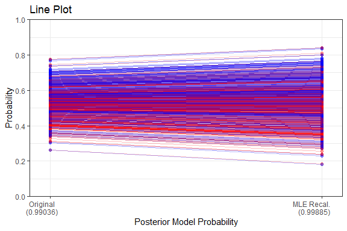

```r
lineplot(hockey$x, hockey$y)
```

Notice the left hand column of points are the original probability predictions. The original probabilities are connect by a line to the MLE recalibrated probabilities in the right hand column. These points and lines are colored based on the corresponding outcome in `y` where blue corresponds to an “event” (i.e. a home team win) and red corresponds to a “non-event” (i.e. a home team loss). For more details on modifying this plot and additional features, see the Visualizing Recalibrated Probability Forecasts via `lineplot()` Section.

## Boldness-Recalibration via `brcal()`

The `brcal` functions allows users to boldness-recalibrate `x` (Guthrie and Franck 2024). More specifically, we are maximizing the standard deviation of the predictions while ensuring the posterior model probability of calibration is at least `t`. By default, `brcal` performs 95% boldness recalibration (i.e. `t` is set to 0.95). Below is an example of 90% boldness-recalibration for FiveThirtyEight’s predictions.

```r
br90 <- brcal(hockey$x, hockey$y, t=0.9)
> iteration: 1
>   x = (0.945397, 1.400573)
>   f(x) = -0.123926
>   g(x) = -0.098849
> iteration: 2
>   x = (0.945397, 1.400573)
>   f(x) = -0.123926
>   g(x) = -0.098849
> iteration: 3
>   x = (0.937285, 1.478607)
>   f(x) = -0.130028
>   g(x) = -0.098758
...

> iteration: 175
>   x = (0.866252, 2.011972)
>   f(x) = -0.169010
>   g(x) = 0.000000
> iteration: 176
>   x = (0.866252, 2.011972)
>   f(x) = -0.169010
>   g(x) = 0.000000
```

Notice there would be quite a bit of output from this call if it were not truncated (4 lines for each of the 176 iterations). This is coming from a call to the `nloptr` function from the `nloptr` package under the hood of `brcal` (Johnson 2007). The `nloptr` package is an R interface to [NLopt](https://nlopt.readthedocs.io/en/latest/), which is an excellent open-source nonlinear optimization library (Johnson 2007). Since both our objective and constraint functions are are nonlinear with respect to parameters $\delta$ and $\gamma$, we leverage the `nloptr` package for the optimization rather than `optim()`. The output printed at each iteration shows (1) the current values of the parameter estimates, (2) the value of the objective function, and (3) the value of the constraint function.

Next, let’s look at the list returned by `brcal()`. The first entry `nloptr` is exactly the object returned from `nloptr()` when the optimizer stops. This provides useful information about convergence and should always be checked by users to ensure that the algorithm converged properly. Next in the list are `Pmc` and `t`, which are just the prior model probability and constraint on probability as specified by the user (or the default values). The solution for the boldness-recalibration parameters is found in `BR_params`. The achieved maximal spread is `sb`. Lastly, `brcal()` returns the vector of boldness-recalibrated probabilities in `probs`.

```r
br90
> $nloptr
>
> Call:
>
> nloptr::nloptr(x0 = c(0.945397, 1.400573), eval_f = obj_f, eval_grad_f = obj_grad_f,
>     eval_g_ineq = constr_g, eval_jac_g_ineq = constr_grad_g,
>     opts = list(algorithm = "NLOPT_LD_AUGLAG", maxeval = 500,
>         maxtime = -1, xtol_rel = 1e-06, print_level = 3, local_opts = list(algorithm = "NLOPT_LD_SLSQP",
>             eval_grad_f = obj_grad_f, eval_jac_g_ineq = constr_grad_g,
>             xtol_rel = 1e-06)), t = 0.9, tau = FALSE, Pmc = 0.5,
>     epsilon = 2.22044604925031e-16)
>
>
> Minimization using NLopt version 2.7.1
>
> NLopt solver status: 4 ( NLOPT_XTOL_REACHED: Optimization stopped because
> xtol_rel or xtol_abs (above) was reached. )
>
> Number of Iterations....: 176
> Termination conditions:  maxeval: 500 xtol_rel: 1e-06
> Number of inequality constraints:  1
> Number of equality constraints:    0
> Optimal value of objective function:  -0.169010301103791
> Optimal value of controls: 0.8662523 2.011972
>
>
>
> $Pmc
> [1] 0.5
>
> $t
> [1] 0.9
>
> $BR_params
> [1] 0.8662523 2.0119717
>
> $sb
> [1] 0.1690103
>
> $probs
>   [1] 0.57521324 0.73683075 0.57447030 0.50109237 0.58118451 0.37458745
>   [7] 0.31759475 0.44828613 0.51755392 0.21761392 0.52264063 0.52633875
>  [13] 0.47812060 0.57725659 0.70072899 0.46208535 0.35630619 0.59785587
...

> [859] 0.60479909 0.45939663 0.35488466 0.72219848 0.70377197 0.45766716
> [865] 0.81088037 0.73320058 0.24804606 0.45772207
```

### Visualizing Boldness-Recalibrated Probabilities via `lineplot()`

We can again use the `lineplot()` function to visualize how the predicted probabilities change from the original set to varying levels of boldness-recalibrated sets. Below we visualize 95% and 90% boldness-recalibration. By default, these will also be compared to the MLE-recalibrated set.

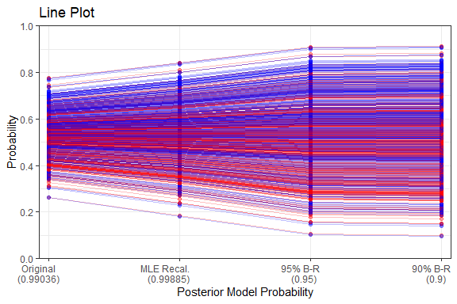

```r
lineplot(x=hockey$x, y=hockey$y, t_levels = c(0.95, 0.9))
```

Notice the left hand column of points are the original probability predictions. The original probabilities are connect by a line to the corresponding MLE-recalibrated, 95%, and 90% boldness-recalibrated probabilities in the right hand columns. These points and lines are colored based on the corresponding outcome in `y` where blue corresponds to an “event” (i.e. a home team win) and red corresponds to a “non-event” (i.e. a home team loss). Notice that the posterior model probabilities on the x-axis are not in ascending or descending order. Instead, they simply follow the ordering of how one might use the `BRcal` package: first looking at the original predictions, then maximizing calibration, then examining how far they can spread out predictions while maintaining calibration with boldness-recalibration. For more details on modifying this plot and additional features, see the Visualizing Recalibrated Probability Forecasts via `lineplot()` Section.

### Using `tau = TRUE`

Sometimes the optimizer is more efficient when optimizing over $\tau = log(\delta)$ instead of $\delta$. In this case, users can set `tau = TRUE`. Specification of start location `x0` and bounds `lb`, `ub` should still be specified in terms of $\delta$. The `brcal` function will automatically convert from $\delta$ to $\tau$. Let’s try optimizing over $\tau$ with the `hockey` data.

```r
br90_tau <- brcal(hockey$x, hockey$y, t=0.9, tau=TRUE)
> iteration: 1
>   x = (-0.056151, 1.400573)
>   f(x) = -0.123926
>   g(x) = -0.098849
> iteration: 2
>   x = (-0.056151, 1.400573)
>   f(x) = -0.123926
>   g(x) = -0.098849
> iteration: 3
>   x = (-0.064262, 1.478607)
>   f(x) = -0.130024
>   g(x) = -0.098758
...

> iteration: 143
>   x = (-0.143578, 2.011970)
>   f(x) = -0.169010
>   g(x) = -0.000002
> iteration: 144
>   x = (-0.143578, 2.011970)
>   f(x) = -0.169010
>   g(x) = -0.000002
```

Notice that the parameter values in the output from `nloptr` are in terms of $\tau$ instead of $\delta$. The same is true of the solution reported in `br90_tau$nloptr`. In general, all results returned directly from `nloptr` will reflect whichever scale `nloptr()` optimized on, whether it be $\delta$ or $\tau$. However, `BR_params` in the returned list will always be reported in terms of $\delta$.

```r
br90_tau
> $nloptr
>
> Call:
>
> nloptr::nloptr(x0 = c(-0.056151, 1.400573), eval_f = obj_f, eval_grad_f = obj_grad_f,
>     eval_g_ineq = constr_g, eval_jac_g_ineq = constr_grad_g,
>     opts = list(algorithm = "NLOPT_LD_AUGLAG", maxeval = 500,
>         maxtime = -1, xtol_rel = 1e-06, print_level = 3, local_opts = list(algorithm = "NLOPT_LD_SLSQP",
>             eval_grad_f = obj_grad_f, eval_jac_g_ineq = constr_grad_g,
>             xtol_rel = 1e-06)), t = 0.9, tau = TRUE, Pmc = 0.5,
>     epsilon = 2.22044604925031e-16)
>
>
> Minimization using NLopt version 2.7.1
>
> NLopt solver status: 4 ( NLOPT_XTOL_REACHED: Optimization stopped because
> xtol_rel or xtol_abs (above) was reached. )
>
> Number of Iterations....: 144
> Termination conditions:  maxeval: 500 xtol_rel: 1e-06
> Number of inequality constraints:  1
> Number of equality constraints:    0
> Optimal value of objective function:  -0.169010174422864
> Optimal value of controls: -0.1435781 2.01197
>
>
>
> $Pmc
> [1] 0.5
>
> $t
> [1] 0.9
>
> $BR_params
> [1] 0.8662531 2.0119700
>
> $sb
> [1] 0.1690102
>
> $probs
>   [1] 0.57521339 0.73683075 0.57447045 0.50109258 0.58118465 0.37458776
>   [7] 0.31759508 0.44828639 0.51755412 0.21761426 0.52264083 0.52633895
>  [13] 0.47812084 0.57725673 0.70072902 0.46208560 0.35630651 0.59785600
...

> [859] 0.60479921 0.45939688 0.35488498 0.72219849 0.70377199 0.45766742
> [865] 0.81088031 0.73320058 0.24804641 0.45772233
```

# Additional Features and Details

In this section, we demonstrate additional features in the `BRcal` package and discuss additional details that may be useful to more advanced use-cases.

## Passing Additional / Different Arguments to `nloptr()`

The nloptr package is extremely flexible, as it provides numerous arguments to users for tailoring the optimization to the problem at hand. In the `nloptr` function, most of these arguments are specified via the `opts` argument, a convention we partially borrow for `brcal()`. However, we allow users to directly specify a few arguments that are typically relegated to `opts` for easier adjustments. All other arguments, except those related to the objective and constraint functions, are available to users by passing a list of these arguments `opts`. We do not allow users to change the objective or constraint functions, or their Jacobian functions, as these are the backbone of this method and the sole purpose for using the `brcal` function. For those who wish to optimize a different function or use a different constraint, we recommend using the `nloptr` function directly.

### Start Values

While the algorithm used by `optim()` was not very sensitive to the starting location of $\delta$ and $\gamma$, we’ve found the nature of boldness-recalibration makes `nloptr()` more sensitive to starting location. By default, `brcal()` initializes the optimization at the MLEs for $\delta$ and $\gamma$. While we’ve found this to be the most stable approach to setting a starting location, users can specify their own starting location by specifying `x0` and setting `start_at_MLEs=FALSE`.

To show the sensitivity of this approach to the starting values, try set `x0` to $\delta = 10$, $\gamma = -5$ like we did with `optim()`. The line of code below will run `brcal()` with these starting values, however we do not run it automatically in this vignette as it causes an error. In this case, the algorithm cannot converge and ends up crashing due to trying extreme values of the parameters. We encourage readers to run this code themselves to verify this result.

```r
try(brcal(hockey$x, hockey$y, x0 = c(10, -5), start_at_MLEs = FALSE))
> iteration: 1
>   x = (10.000000, -5.000000)
>   f(x) = -0.264782
>   g(x) = 0.950000
> iteration: 2
>   x = (10.000000, -5.000000)
>   f(x) = -0.264782
>   g(x) = 0.950000
> iteration: 3
>   x = (9.994848, -5.044965)
>   f(x) = -0.266818
>   g(x) = 0.950000
...

> iteration: 27
>   x = (3.550802, -324.404849)
>   f(x) = -0.476697
>   g(x) = 0.950000
> iteration: 28
>   x = (4.390822, -445.720424)
>   f(x) = -0.477751
>   g(x) = 0.950000
> iteration: 29
>   x = (5.542112, -615.971882)
>   f(x) = nan
> Error in optim(par = par, fn = llo_lik, ..., x = x, y = y, neg = TRUE,  :
>   function cannot be evaluated at initial parameters
```

### Algorithm

By default, the `brcal` function uses the Augmented Lagrangian Algorithm (AUGLAG) (Conn, Gould, and Toint 1991; Birgin and Martínez 2008), which requires an inner optimization routine. We use Sequential Least-Squares Quadratic Programming (SLSQP) (Kraft 1988, 1994) as the inner optimization routine, by default. For a complete list of inner and outer optimization algorithms, see the [NLopt website.](https://nlopt.readthedocs.io/en/latest/) Note that not all algorithms can be used with a non-linear constraint (which is necessary for boldness-recalibration). Also note that other algorithms may be more sensitive to starting conditions or may need different stopping criteria to converge.

All changes to the inner algorithm are made via passing a sub-list to `local_opts`, which itself an entry of the list passed to `opts`. Instead of SLSQP as the inner algorithm, let’s try the method of moving asymptotes (MMA) (Svanberg 2002).

```r
br90_inMMA <- brcal(hockey$x, hockey$y, t=0.9,
                    opts=list(local_opts=list(algorithm="NLOPT_LD_MMA")))
> iteration: 1
>   x = (0.945397, 1.400573)
>   f(x) = -0.123926
>   g(x) = -0.098849
> iteration: 2
>   x = (0.945397, 1.400573)
>   f(x) = -0.123926
>   g(x) = -0.098849
...

> iteration: 104
>   x = (0.866252, 2.011971)
>   f(x) = -0.169010
>   g(x) = -0.000001
> iteration: 105
>   x = (0.866252, 2.011971)
>   f(x) = -0.169010
>   g(x) = -0.000001
```

```r
br90_inMMA$nloptr
>
> Call:
>
> nloptr::nloptr(x0 = c(0.945397, 1.400573), eval_f = obj_f, eval_grad_f = obj_grad_f,
>     eval_g_ineq = constr_g, eval_jac_g_ineq = constr_grad_g,
>     opts = list(local_opts = list(algorithm = "NLOPT_LD_MMA",
>         eval_f = obj_f, eval_grad_f = obj_grad_f, eval_g_ineq = constr_g,
>         eval_jac_g_ineq = constr_grad_g, xtol_rel = 1e-06), algorithm = "NLOPT_LD_AUGLAG",
>         maxeval = 500, xtol_rel = 1e-06, print_level = 3), t = 0.9,
>     tau = FALSE, Pmc = 0.5, epsilon = 2.22044604925031e-16)
>
>
> Minimization using NLopt version 2.7.1
>
> NLopt solver status: 4 ( NLOPT_XTOL_REACHED: Optimization stopped because
> xtol_rel or xtol_abs (above) was reached. )
>
> Number of Iterations....: 105
> Termination conditions:  maxeval: 500 xtol_rel: 1e-06
> Number of inequality constraints:  1
> Number of equality constraints:    0
> Optimal value of objective function:  -0.169010270051815
> Optimal value of controls: 0.8662522 2.011971
```

Now, let’s try changing the outer algorithm to MMA. This is a great example of an algorithm that is more sensitive to both starting conditions and stopping criteria. In order to get convergence here, we’ll opt to start the optimizer at `c(1,2)` and relax the relative tolerance. Stopping criteria is discussed in a later section.

```r
br90_outMMA <- brcal(hockey$x, hockey$y, t=0.9, x0=c(1, 2), start_at_MLEs = FALSE,
                     xtol_rel_outer = 1e-05,
                     opts=list(algorithm="NLOPT_LD_MMA"))
> iteration: 1
>   x = (1.000000, 2.000000)
>   f(x) = -0.166367
>   g(x) = 0.229068
> iteration: 2
>   x = (0.938217, 2.023699)
>   f(x) = -0.168894
>   g(x) = 0.075137
...

> iteration: 15
>   x = (0.866256, 2.011972)
>   f(x) = -0.169010
>   g(x) = 0.000000
> iteration: 16
>   x = (0.866238, 2.011969)
>   f(x) = -0.169010
>   g(x) = -0.000000
```

```r
br90_outMMA$nloptr
>
> Call:
> nloptr::nloptr(x0 = c(1, 2), eval_f = obj_f, eval_grad_f = obj_grad_f,
>     eval_g_ineq = constr_g, eval_jac_g_ineq = constr_grad_g,
>     opts = list(algorithm = "NLOPT_LD_MMA", maxeval = 500, xtol_rel = 1e-05,
>         print_level = 3, local_opts = list(algorithm = "NLOPT_LD_SLSQP",
>             eval_grad_f = obj_grad_f, eval_jac_g_ineq = constr_grad_g,
>             xtol_rel = 1e-06, eval_f = obj_f, eval_g_ineq = constr_g)),
>     t = 0.9, tau = FALSE, Pmc = 0.5, epsilon = 2.22044604925031e-16)
>
>
> Minimization using NLopt version 2.7.1
>
> NLopt solver status: 4 ( NLOPT_XTOL_REACHED: Optimization stopped because
> xtol_rel or xtol_abs (above) was reached. )
>
> Number of Iterations....: 16
> Termination conditions:  maxeval: 500 xtol_rel: 1e-05
> Number of inequality constraints:  1
> Number of equality constraints:    0
> Optimal value of objective function:  -0.169010299710146
> Optimal value of controls: 0.8662376 2.011969
```

Note that many of the algorithms do not use an inner algorithm. In most of these cases, `local_opts` will be ignored, otherwise `nloptr()` may throw a warning or error.

### Bounds

Following the convention of `nloptr()`, arguments `lb` and `ub` allow users to specify the lower and upper bounds of optimization, respectively. The bounds set using `lb` and `ub` are used for both the inner and outer algorithms. By default, we only place a lower bound on $\delta$ requiring $\delta > 0$. Similar to setting the bounds of optimization in `optim()`, setting the lower bound to `-Inf` and the upper bound to `Inf` will leave the corresponding parameter unbounded.

For example, the code below shows how to bound $0.25 < \delta < 5$ and leave $\gamma$ unbounded.

```r
br90_bound <- brcal(hockey$x, hockey$y, t=0.9, lb=c(0.25, -Inf), ub=c(5, Inf))
> iteration: 1
>   x = (0.945397, 1.400573)
>   f(x) = -0.123926
>   g(x) = -0.098849
> iteration: 2
>   x = (0.945397, 1.400573)
>   f(x) = -0.123926
>   g(x) = -0.098849
...

> iteration: 175
>   x = (0.866252, 2.011972)
>   f(x) = -0.169010
>   g(x) = 0.000000
> iteration: 176
>   x = (0.866252, 2.011972)
>   f(x) = -0.169010
>   g(x) = 0.000000
```

```r
br90_bound$nloptr
>
> Call:
>
> nloptr::nloptr(x0 = c(0.945397, 1.400573), eval_f = obj_f, eval_grad_f = obj_grad_f,
>     eval_g_ineq = constr_g, eval_jac_g_ineq = constr_grad_g,
>     opts = list(algorithm = "NLOPT_LD_AUGLAG", maxeval = 500,
>         maxtime = -1, xtol_rel = 1e-06, print_level = 3, local_opts = list(algorithm = "NLOPT_LD_SLSQP",
>             eval_grad_f = obj_grad_f, eval_jac_g_ineq = constr_grad_g,
>             xtol_rel = 1e-06)), t = 0.9, tau = FALSE, Pmc = 0.5,
>     epsilon = 2.22044604925031e-16)
>
>
> Minimization using NLopt version 2.7.1
>
> NLopt solver status: 4 ( NLOPT_XTOL_REACHED: Optimization stopped because
> xtol_rel or xtol_abs (above) was reached. )
>
> Number of Iterations....: 176
> Termination conditions:  maxeval: 500 xtol_rel: 1e-06
> Number of inequality constraints:  1
> Number of equality constraints:    0
> Optimal value of objective function:  -0.169010301103791
> Optimal value of controls: 0.8662523 2.011972
```

### Stopping criteria

Since there are quite a few options for stopping criteria that can be set via `opts` in the `nloptr` function, we select just a few to specify directly in the `brcal` function. As with `optim()`, it is important to check convergence and adjust the stopping criteria accordingly. Keep in mind that stopping criteria also work together so several adjustments may be necessary.

Argument `maxeval` sets the maximum number of iterations (approximately) allowed by the outer optimization routine. Argument `maxtime` sets the maximum number of seconds (approximately) the outer algorithm will be allowed to run. Argument `xtol_rel_outer` and `xtol_rel_inner` set the relative tolerance for the change in $\delta$ and $\gamma$ between iterations of the outer and inner algorithms, respectively. Again, `nloptr` allows several other options for stopping criteria that can be specified via `opts`.

The example below shows how to set the maximum number of evaluations to 100, the maximum time to 30 seconds, and the relative tolerance of both the inner and outer algorithms to 0.001. These are not necessarily recommended settings, rather they are intended for demonstration purposes only.

```r
br90_stop <- brcal(hockey$x, hockey$y, t=0.9, maxeval=100, maxtime = 30,
      xtol_rel_outer = 0.001, xtol_rel_inner = 0.001)
> iteration: 1
>   x = (0.945397, 1.400573)
>   f(x) = -0.123926
>   g(x) = -0.098849
> iteration: 2
>   x = (0.945397, 1.400573)
>   f(x) = -0.123926
>   g(x) = -0.098849
...

> iteration: 82
>   x = (0.866252, 2.011972)
>   f(x) = -0.169010
>   g(x) = -0.000000
> iteration: 83
>   x = (0.866252, 2.011972)
>   f(x) = -0.169010
>   g(x) = -0.000000
```

```r
br90_stop$nloptr
>
> Call:
>
> nloptr::nloptr(x0 = c(0.945397, 1.400573), eval_f = obj_f, eval_grad_f = obj_grad_f,
>     eval_g_ineq = constr_g, eval_jac_g_ineq = constr_grad_g,
>     opts = list(algorithm = "NLOPT_LD_AUGLAG", maxeval = 100,
>         maxtime = 30, xtol_rel = 0.001, print_level = 3, local_opts = list(algorithm = "NLOPT_LD_SLSQP",
>             eval_grad_f = obj_grad_f, eval_jac_g_ineq = constr_grad_g,
>             xtol_rel = 0.001)), t = 0.9, tau = FALSE, Pmc = 0.5,
>     epsilon = 2.22044604925031e-16)
>
>
> Minimization using NLopt version 2.7.1
>
> NLopt solver status: 4 ( NLOPT_XTOL_REACHED: Optimization stopped because
> xtol_rel or xtol_abs (above) was reached. )
>
> Number of Iterations....: 83
> Termination conditions:  maxeval: 100 maxtime: 30 xtol_rel: 0.001
> Number of inequality constraints:  1
> Number of equality constraints:    0
> Optimal value of objective function:  -0.169010294069083
> Optimal value of controls: 0.8662524 2.011972
```

### Suppressing output from `nloptr()`

To minimize the amount of output printed at each iteration of the optimizer, we leverage `print_level` from `nloptr()`. By default, we choose to print the maximum amount of information by setting `print_level=3`. To simply reduce the output, try `print_level=1`…

```r
br90 <- brcal(hockey$x, hockey$y, t=0.9, print_level=1)
> iteration: 1
>   f(x) = -0.123926
> iteration: 2
>   f(x) = -0.123926
> iteration: 3
>   f(x) = -0.130028
...

> iteration: 174
>   f(x) = -0.169010
> iteration: 175
>   f(x) = -0.169010
> iteration: 176
>   f(x) = -0.169010
```

…or `print_level=2`.

```r
br90 <- brcal(hockey$x, hockey$y, t=0.9, print_level=2)
> iteration: 1
>   f(x) = -0.123926
>   g(x) = -0.098849
> iteration: 2
>   f(x) = -0.123926
>   g(x) = -0.098849
> iteration: 3
>   f(x) = -0.130028
>   g(x) = -0.098758
...

> iteration: 174
>   f(x) = -0.169010
>   g(x) = 0.000000
> iteration: 175
>   f(x) = -0.169010
>   g(x) = 0.000000
> iteration: 176
>   f(x) = -0.169010
>   g(x) = 0.000000
```

Or to fully suppress, use `print_level=0`. Notice nothing prints from the following call.

```r
br90 <- brcal(hockey$x, hockey$y, t=0.9, print_level=0)
```

## Passing Additional / Different Arguments to `optim()`

While `optim()` is not used for the non-linear constrained optimization for finding the boldness-recalibration parameters, it is used throughout this package wherever the MLEs are needed, including in the calculation for the posterior model posterior (`bayes_ms()`, `llo_lrt()`, `mle_recal`, `brcal()`, `line_plot()`, and `plot_params()`).

While we’ve found that `optim()` converges in most cases we’ve tried using the default settings in this package, it is important to double check convergence. It is for this reason that we allow users to pass additional arguments to `optim` and include the returned list from `optim()` in several of our own functions so users can see the convergence information. If the algorithm did not converge, which can be checked via list elements `optim_details$convergence` and `optim_details$message` from `bayes_ms()`, `llo_lrt()`, or `mle_recal()`, users should adjust the arguments passed to `optim()` using `...` to achieve convergence before trusting results. Below are a few examples of how to adjust the call to `optim()`. See the documentation for `optim()` for more information.

### Conventions for Passing Arguments to `optim()`

The BRcal package uses two different conventions for passing arguments to `optim()` depending on the situation. For the functions where `optim()` is the only function to which we are passing additional arguments (`bayes_ms()`, `llo_lrt()`, and `mle_recal()`), we pass arguments to `optim()` using the `...`. The next few sections demonstrate how to pass arguments in this way. While the examples in this section use `bayes_ms()`, the same conventions apply to `llo_lrt()` and `mle_recal()`.

For the functions where we pass additional arguments to multiple functions (`brcal()`, `plot_params()`, and `lineplot()`), we cannot leverage the flexibility of `...`. Instead, users can pass arguments to `optim()` in the form of a list via `optim_options`. Demonstration of passing arguments to `optim()` in this fashion can be found in Passing Arguments via a List.

### Start Values

In the following example, we will start the optimizer at $\delta = 10$, $\gamma = -5$.

```r
bayes_ms(hockey$x, hockey$y, par = c(10, -5))
> $Pmc
> [1] 0.5
>
> $BIC_Mc
> [1] 1148.637
>
> $BIC_Mu
> [1] 1157.902
>
> $BF
> [1] 0.009730526
>
> $posterior_model_prob
> [1] 0.9903632
>
> $MLEs
> [1] 0.9455187 1.4004799
>
> $optim_details
> $optim_details$par
> [1] 0.9455187 1.4004799
>
> $optim_details$value
> [1] 572.1846
>
> $optim_details$counts
> function gradient
>       61       NA
>
> $optim_details$convergence
> [1] 0
>
> $optim_details$message
> NULL
```

In this case, the optimizer does not seem overly sensitive to start values, as $\delta = 10$, $\gamma = -5$ are not close to the solution (the MLEs) at $\delta = 0.9455$, $\gamma = 1.4005$. The algorithm converged and we get the same solution as when we started at $\delta = 0.5$, $\gamma = 0.5$.

### Stopping Criteria

Sometimes it’s useful to adjust the optimization stopping criteria to improve convergence or refine the solution. We use the default settings in `optim()`. These can be adjust via the argument `control` which takes a list with an array of possible components. We defer to the documentation for `optim()` for further explanation of how to use `control`. Below is a simple example where we set the relative convergence tolerance (`reltol`) to `1e-10` instead of the default of `sqrt(.Machine$double.eps)`.

```r
bayes_ms(hockey$x, hockey$y, control=list(reltol=1e-10))
> $Pmc
> [1] 0.5
>
> $BIC_Mc
> [1] 1148.637
>
> $BIC_Mu
> [1] 1157.902
>
> $BF
> [1] 0.009730632
>
> $posterior_model_prob
> [1] 0.9903631
>
> $MLEs
> [1] 0.945395 1.401402
>
> $optim_details
> $optim_details$par
> [1] 0.945395 1.401402
>
> $optim_details$value
> [1] 572.1846
>
> $optim_details$counts
> function gradient
>       83       NA
>
> $optim_details$convergence
> [1] 0
>
> $optim_details$message
> NULL
```

Notice how we arrive at a slightly different solution and there were more function calls than when using the default.